# Practical Machine Learning Course Project

Ankitha Giridhar

19/10/2021

### Overview

Data can now be collected from fitness trackers. Many fitness enthusiasts take measurements about their activity quite regularly, generally focusing on quantifying their activity.However, the quality of the exercise must also be taken into consideration. In this project, data from accelerometers on the belt, forearm, arm, and dumbbells of 6 participants, who were asked to perform barbell lifts correctly and incorrectly in 5 different ways. The goal was to predict the classe variable, which indicates the manner in which they did this.

### Relevant Libraries

The libraries relevant for the project are loaded, and the seed is set to 12

```r
library(lattice)
```

```r
library(ggplot2)
library(caret)
library(kernlab)
library(rattle)
library(corrplot)
library(randomForest)
set.seed(12)
```

### Loading the Data

The train and test files are read into train_set and test from their urls. The dimensions of train_set and test give an initial idea of the size of the data.

```r
train_link <- "http://d396qusza40orc.cloudfront.net/predmachlearn/pml-training.csv"
train_set <- read.csv(url(train_link))
test_link <- "http://d396qusza40orc.cloudfront.net/predmachlearn/pml-testing.csv"
test <- read.csv(url(test_link))
dim(train_set)
```

```
## [1] 19622   160
```

```r
dim(test)
```

```
## [1]  20 160
```

### Cleaning the Data

The NA values are removed from the train_set as are the variables near zero variance.

```r
#Removing NA values
train_set <- train_set[,colMeans(is.na(train_set)) < .9]
train_set <- train_set[,-c(1:7)]
#Removing variables near zero variance
nzv <- nearZeroVar(train_set)
train_set <- train_set[, -nzv]
dim(train_set)
```

```
## [1] 19622    53
```

The change in the dimension of train from (19622,160) to (19622,53) represents the cleaning done.

### Splitting the Data

The data is split into the training and validation subsets with a ratio of 0.7.

```r
train_part <- createDataPartition(train_set$classe, p=0.7, list=FALSE)
train <- train_set[train_part, ]
val  <- train_set[-train_part, ]
dim(train)
```

```
## [1] 13737    53
```

```r
dim(val)
```

```
## [1] 5885   53
```

### Correlations

Before launching into the actual models and predictions, the train set is examined for correlations.

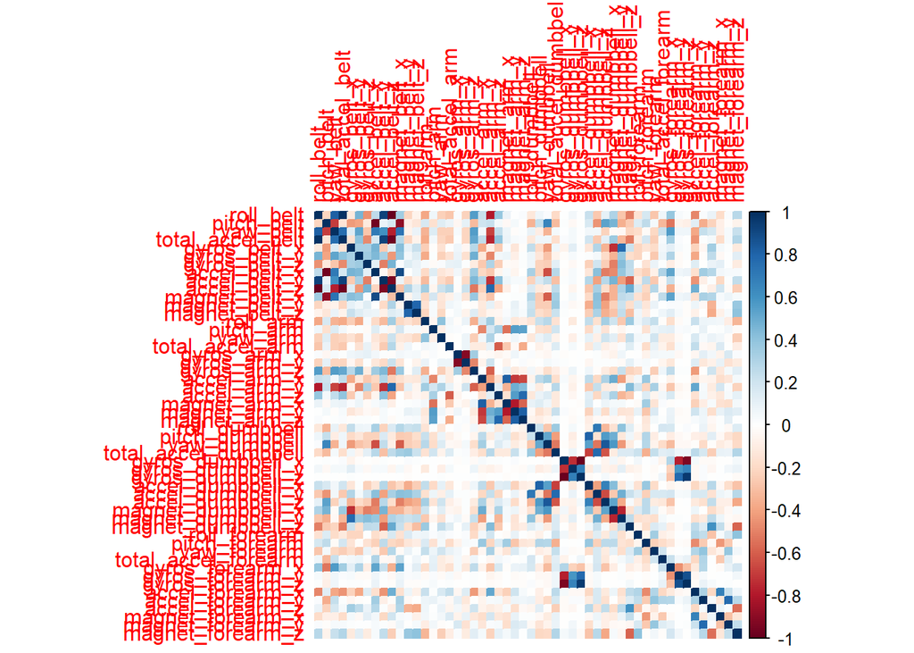

```r
corrPlot <- cor(train[, -length(names(train))])
corrplot(corrPlot, method="color")
```

### Cross Validation

```r
control <- trainControl(method="cv", number=3, verboseIter=F)
```

### The Decision Tree Model

The first model tried out is the decision tree model. The tree is visualized after training.

[figure not shown]

```r
dt_model <- train(classe~., data=train, method="rpart", trControl = control, tuneLength = 5)
fancyRpartPlot(dt_model$finalModel)
```

```r
val_preds_dt <- predict(dt_model,val)
confusionMatrix(val_preds_dt, as.factor(val$classe))
```

```
## Confusion Matrix and Statistics
##
##           Reference
## Prediction    A    B    C    D    E
##          A 1531  471  464  429  161
##          B   18  332   24    8  124
##          C   93  256  417  116  230
##          D   31   80  121  411   76
##          E    1    0    0    0  491
##
## Overall Statistics
##
##                Accuracy : 0.5407
##                  95% CI : (0.5279, 0.5535)
##     No Information Rate : 0.2845
##     P-Value [Acc > NIR] : < 2.2e-16
##
##                   Kappa : 0.4014
##
##  Mcnemar's Test P-Value : < 2.2e-16
##
## Statistics by Class:
##
##                      Class: A Class: B Class: C Class: D Class: E
## Sensitivity            0.9146  0.29148  0.40643  0.42635  0.45379
## Specificity            0.6379  0.96334  0.85697  0.93741  0.99979
## Pos Pred Value         0.5010  0.65613  0.37500  0.57163  0.99797
## Neg Pred Value         0.9495  0.84997  0.87241  0.89295  0.89041
## Prevalence             0.2845  0.19354  0.17434  0.16381  0.18386
## Detection Rate         0.2602  0.05641  0.07086  0.06984  0.08343
## Detection Prevalence   0.5193  0.08598  0.18895  0.12218  0.08360
## Balanced Accuracy      0.7762  0.62741  0.63170  0.68188  0.72679
```

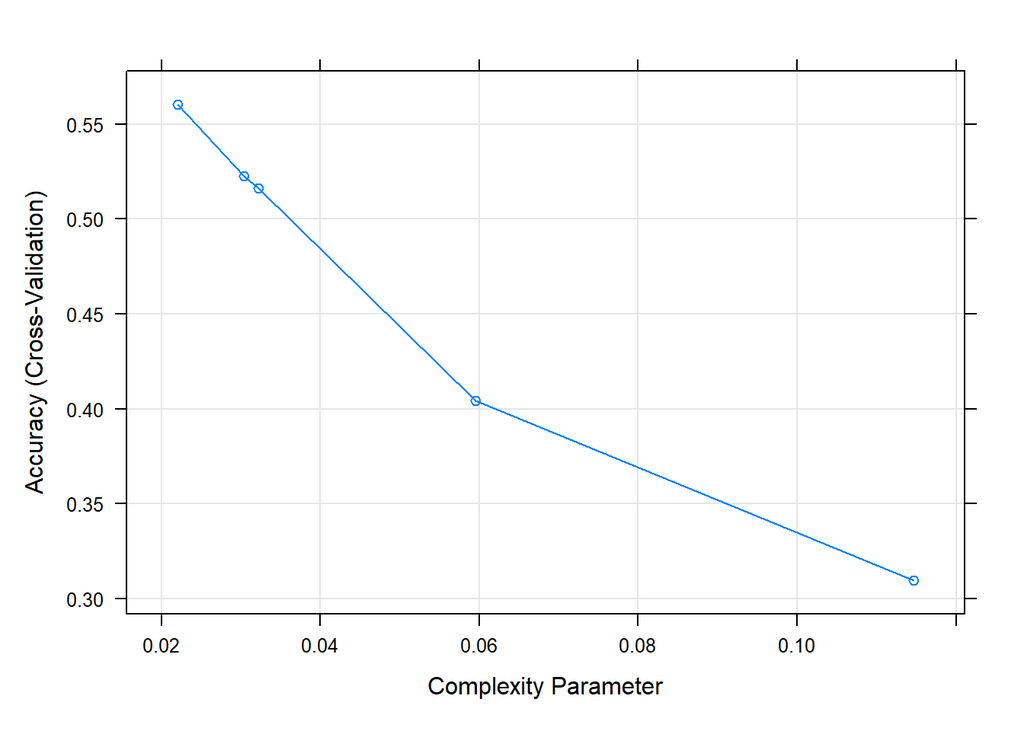

```r
plot(dt_model)
```

The accuracy of this model is 54.07%. Hence, other models need to be explored.

### The Generalized Boosted Model

The second model explored is the generalized boosted model.

```r
gb_model <- train(classe~., data=train, method="gbm", trControl = control, tuneLength = 5)
val_preds_gb <- predict(gb_model,val)
confusionMatrix(val_preds_gb, as.factor(val$classe))
```

```
## Confusion Matrix and Statistics
##
##           Reference
## Prediction    A    B    C    D    E
##          A 1666    7    0    0    0
##          B    6 1121    9    0    3
##          C    1   11 1012   10    3
##          D    1    0    5  951    8
##          E    0    0    0    3 1068
##
## Overall Statistics
##
##                Accuracy : 0.9886
##                  95% CI : (0.9856, 0.9912)
##     No Information Rate : 0.2845
##     P-Value [Acc > NIR] : < 2.2e-16
##
##                   Kappa : 0.9856
##
##  Mcnemar's Test P-Value : NA
##
## Statistics by Class:
##
##                      Class: A Class: B Class: C Class: D Class: E
## Sensitivity            0.9952   0.9842   0.9864   0.9865   0.9871
## Specificity            0.9983   0.9962   0.9949   0.9972   0.9994
## Pos Pred Value         0.9958   0.9842   0.9759   0.9855   0.9972
## Neg Pred Value         0.9981   0.9962   0.9971   0.9974   0.9971
## Prevalence             0.2845   0.1935   0.1743   0.1638   0.1839
## Detection Rate         0.2831   0.1905   0.1720   0.1616   0.1815
## Detection Prevalence   0.2843   0.1935   0.1762   0.1640   0.1820
## Balanced Accuracy      0.9968   0.9902   0.9906   0.9918   0.9932
```

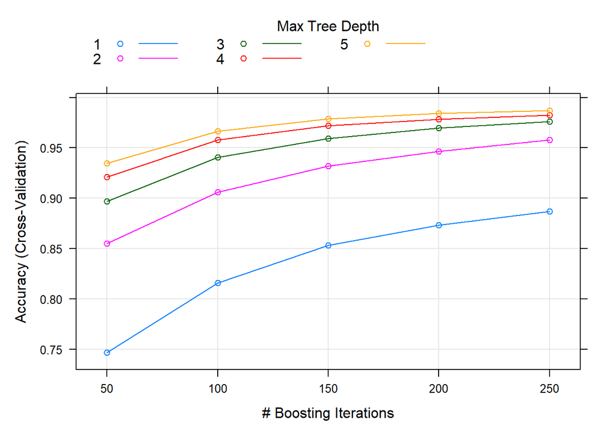

```r
plot(gb_model)
```

### The Random Forest Classifier

```r
rf_model <- train(classe~., data=train, method = 'rf', trControl = control, tuneLength = 5)
val_preds_rf <- predict(rf_model,val)
confusionMatrix(val_preds_rf, as.factor(val$classe))
```

```
## Confusion Matrix and Statistics
##
##           Reference
## Prediction    A    B    C    D    E
##          A 1672    4    0    0    0
##          B    2 1132    4    0    0
##          C    0    3 1020    4    0
##          D    0    0    2  959    1
##          E    0    0    0    1 1081
##
## Overall Statistics
##
##                Accuracy : 0.9964
##                  95% CI : (0.9946, 0.9978)
##     No Information Rate : 0.2845
##     P-Value [Acc > NIR] : < 2.2e-16
##
##                   Kappa : 0.9955
##
##  Mcnemar's Test P-Value : NA
##
## Statistics by Class:
##
##                      Class: A Class: B Class: C Class: D Class: E
## Sensitivity            0.9988   0.9939   0.9942   0.9948   0.9991
## Specificity            0.9991   0.9987   0.9986   0.9994   0.9998
## Pos Pred Value         0.9976   0.9947   0.9932   0.9969   0.9991
## Neg Pred Value         0.9995   0.9985   0.9988   0.9990   0.9998
## Prevalence             0.2845   0.1935   0.1743   0.1638   0.1839
## Detection Rate         0.2841   0.1924   0.1733   0.1630   0.1837
## Detection Prevalence   0.2848   0.1934   0.1745   0.1635   0.1839
## Balanced Accuracy      0.9989   0.9963   0.9964   0.9971   0.9994
```

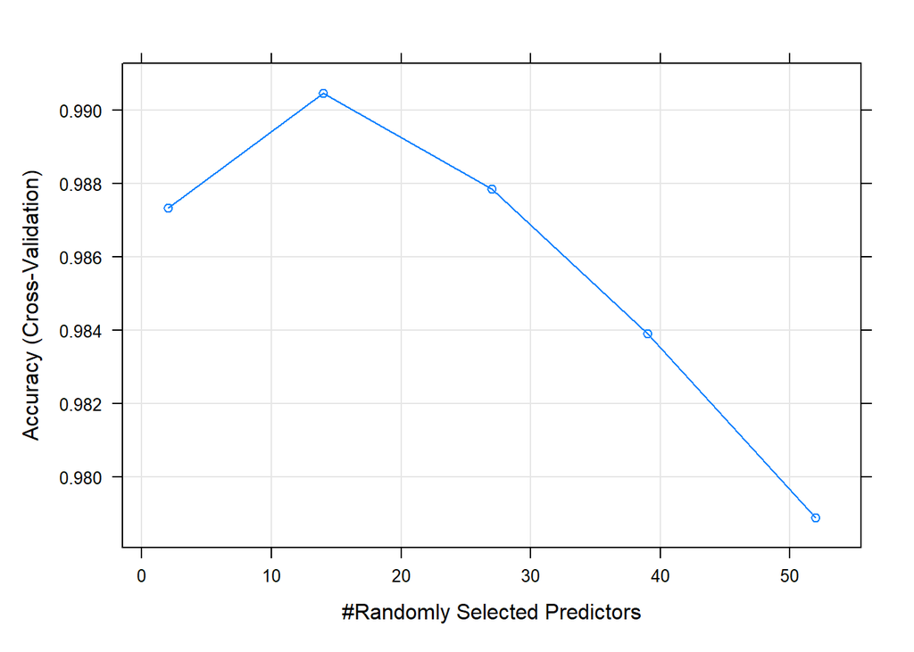

```r
plot(rf_model)
```

### Predictions on the Test Set

The best model, i.e. the random forest model was used to make the final predictions on the test set.

```r
pred <- predict(rf_model, test)
print(pred)
```

```
##  [1] B A B A A E D B A A B C B A E E A B B B
## Levels: A B C D E
```